# Example Interactive Graphs

Matthew Martinez

4/3/2020

## Transitions Analysis

I can discuss what this study is about **here**. Including formating and working with R Markdown within this example. Click here for RStudio

Next, I discuss the results of this assessment.

## Results

[interactive chart not shown]

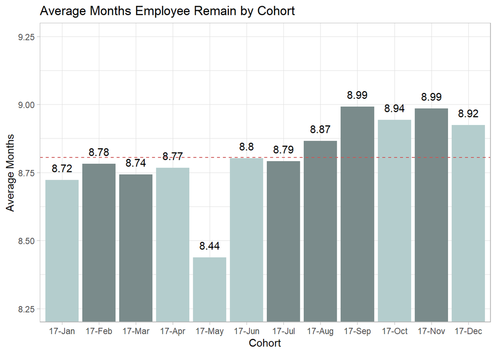

Next we see Figure #3 which displays the percent of employees that remain over time. The month number on the x-axis corresponds to the month of observation for each cohort. For example, month number 102 is the second month for the Feb17 cohort which would be March17, but the second month for the July17 cohort is August17 and so on. This allows us to view trends over time per cohort. The dashed vertical line symbolizes the 6th month, or when employees should convert to full-time status according to policy rules. As one can see for all cohorts, at least 70% of employees reamin as part-time after 6 months. The 17-Nov cohort has the largest percentage of part-time employees remaining at 76.15 and the 17-May cohort has the least part-time employees remaining at 70.58.

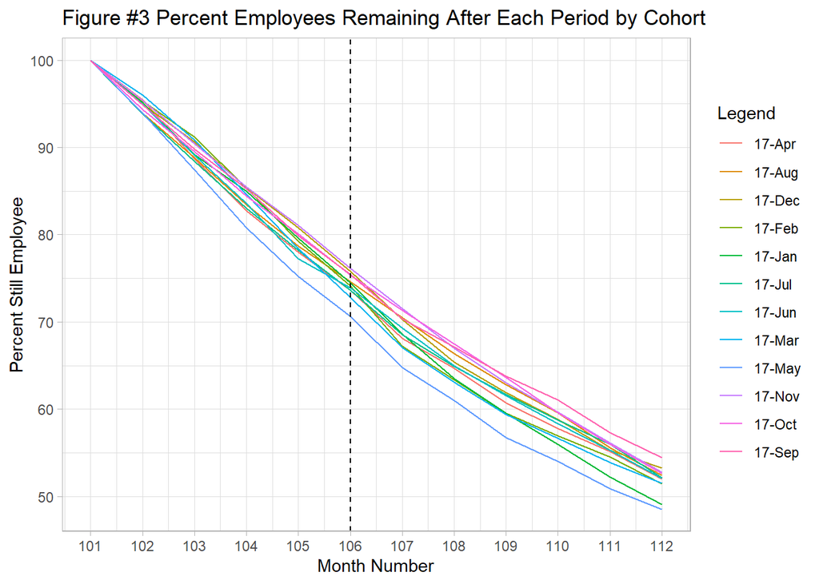

I am providing Google Visualizations

[output not shown]

## Appendix

I am providing the following table that displays the top 15 transitions made from the part-time status. As can be seen, the data contain some missing values (‘NA’). This can potentially be an important factor when analyzing the data above. These NA’s can mean one of two things, each with different affects on the analyses. The NAs could mean that the previous status is still in effect or they could mean that there was a transition but this status change was not correctly documented.

[interactive chart not shown]